# Agregar un nivel de agrupamiento a una base de datos existente

Martín Paladino[^1]

25 de febrero de 2017

> Never do loops and roll a join from time to time.

# 1 Definición general del problema.

Con frecuencia los datos con los que trabajamos están agrupados, es decir, se pueden dividir en múltiples cateogrías. Algunos de estos agrupamientos son sólo eso, categorías que podemos cruzar como mejor nos parezca. Sin embargo, en algunos casos esos grupos guardan un orden de pertenencia estricto: todos los datos de cierto grupo pertenecen a su vez a un grupo más amplio y al mismo tiempo no pertenecen a ningún otro. Veamos un ejemplo en dos tablas:

Datos mutuamente independientes

| Fila | Nivel educativo | Género |
| --- | --- | --- |
| 1 | Primaria | Masculino |
| 2 | Universidad | Masculino |
| 3 | Primaria | Femenino |
| 4 | Secundaria | Femenino |
| 5 | Primaria | Femenino |
| 6 | Primaria | Masculino |

Datos jerárquicos

| Fila | Continente | País |
| --- | --- | --- |
| 1 | América | México |
| 2 | América | Jamaica |
| 3 | América | Uruguay |
| 4 | Europa | Croacia |
| 5 | Europa | Luxemburgo |
| 6 | Europa | San Marino |

El problema práctico que queremos resolver es agregar a una base de datos una nueva columna en la que incluyamos un nuevo nivel de agrupamiento jerárquico. El primer paso es verificar que nuestros datos tengan una estructura jerárquica, de lo contrario estamos ante un problema diferente. Cada fila de los datos originales debe pertenecer a uno y sólo uno de los grupos que queremos agregar.

# 2 Agregar un nivel jerárquico más amplio usando R.

En este ejemplo práctico tomaremos la base de CONAPO del Índice de Marginación a nivel municipal, que ya incluye un orden jerárquico de Entidades y Municipios. Cada municipio pertenece solamente a una entidad. Queremos agregar las regiones a las que pertenece cada Entidad, un nivel de jerarquía más alto. Es necesario, por lo tanto, conocer a qué región pertenece cada Entidad. Vamos a tomar una [regionalización](https://es.wikipedia.org/wiki/Regiones_de_México) muy simple, sólo a los efectos de desarrollar el problema práctico.

Hay varias aproximaciones a este problema. La más directa y laboriosa es editar manualmente los datos y agregar la región a cada fila. Con 14641 filas en total no es una gran idea, llevaría mucho tiempo y además este procedimiento es propenso a errores. Mejor automatizarlo, para algo instalamos R en nuestra computadora.

Para automatizarlo también tenemos varias opciones. En cualquiera de las opciones vamos necesitar al menos dos estructuras de datos, la base con la información de Entidades y Municipios y alguna otra estructura que especifica a qué región pertenece cada Entidad. Luego debemos pasar esos datos a alguna función o funciones para que cree la columna “REGION”, que en cada fila tendrá el nombre de la región corresponde a esa observación. La columna REGION deberá tener un largo de 14641, es decir, el mismo largo que la base de datos.

```r
#Carga de librerías.

library(tidyverse)
library(knitr)

#Cargamos la base directamente del sítio de CONAPO.

base_marginacion <- read_csv("http://www.conapo.gob.mx/work/models/CONAPO/Marginacion/Datos_Abiertos/Municipio/Base_Indice_de_marginacion_municipal_90-15.csv",col_types = cols(`AÑO` = col_character())) %>%
  select(-`<U+FEFF>CVE_MUN`, -CVEE_MUN, -VP) %>%                   #Elimino algunas columnas que no necesito.
  mutate (POB_TOT=gsub(" ","", POB_TOT)) %>%                       #Quito el espacio que separa a los miles en población total...
  mutate(POB_TOT=as.integer(POB_TOT)) %>%                          #y lo paso a numérico.
  filter(ENT!="Nacional")                                          #Elimino los datos agregados.
```

Una primera aproximación es usar una función de recodificación condicional. La condición que vamos a verificar es de pertenencia, por lo que usaremos el operador `%in%` que verifica si un elemento pertenece o no a un conjunto y regresa `TRUE` o `FALSE` según sea el caso.

El conjunto al que las Entidades pertenecerán o no está definido por cada región. Como el número de Entidades por región es desigual no es viable usar una estructura rectangular como el data.frame, por lo tanto definiremos a cada conjunto/región como un vector atómico, para mantener las cosas simples[^2] El vector Sur_oeste incluye a los Estados de Chiapas, Oaxaca y Guerrero, y así con los 7 restantes. Es fundamental no cometer error ortográfico alguno, de espacios, puntuación, etc. Para el evaluador lógico de R `Mexico` y `México` son completamente diferentes. El siguiente paso es programar una función que verifique fila por fila el nombre de la Entidad -la columna ENT-, revise a qué conjunto/vector pertenece y asigne el nombre del vector correcto en la columna REG de cada fila.

## 2.1 Opción 1. Un bucle.

La opción 1 es una forma muy clásica de programar una función para que haga algo si se cumple cierta condición. Si tiene experiencia en otros lenguajes de programación seguramente fue la primera en la que pensó. En este caso usamos dos estructuras de control anidadas: la estructura `for()` para hacer que el evaluador de R circule fila por fila. En cada paso del bucle el índice `i` aumenta una unidad, partiendo de 1 hasta llegar a `nrow(base_marginacion)` o 14641. En cada paso/fila evalúa los 8 `if()` y, cuando se cumple la condición (es decir, la Entidad pertenece al vector en cuestión) asigna con `=` el nombre correcto en la columna `REG`. Esta función modifica directamente la estructura de datos base_marginacion, es decir, como función no tiene un output, sólo produce efectos secundarios. Las posibilidades de que un error de sintaxis o de concepto en la definición de la función corrompa los datos son muy altas.

```r
#Generamos un conjunto vectores con la jerarquía de Regiones y entidades.
Noroeste <- c("Baja California", "Baja California Sur", "Chihuahua", "Durango", "Sinaloa", "Sonora")
Noreste <- c("Coahuila de Zaragoza","Nuevo León","Tamaulipas")
Oeste <- c("Colima","Jalisco", "Michoacán de Ocampo","Nayarit")
Este <- c("Hidalgo","Puebla","Tlaxcala","Veracruz de Ignacio de la Llave")
Centro_norte <- c("Aguascalientes", "Guanajuato","Querétaro de Arteaga","San Luis Potosí","Zacatecas")
Centro_sur <- c("Distrito Federal","México","Morelos")
Sur_oeste <- c("Chiapas","Guerrero","Oaxaca")
Sur_este <- c("Campeche", "Quintana Roo","Tabasco","Yucatán")

base_marginacion2 <- base_marginacion #Guardo una copia del objeto original porque habrá efectos colaterales.

#Opción 1. Un bucle. Solución en R MUY base. Dos malas prácticas de programación en una: bucles y efectos secundarios.

for(i in 1:nrow(base_marginacion)){           #i es el índice, 1:nrow es una secuencia de enteros de 1 hasta el número de filas de la base de datos (14641)
  if (base_marginacion$ENT[i] %in% Noroeste){  #Si base_marginacion en la fila i está en Noroeste...
    base_marginacion$REG[i] = "Noroeste"}      #base_marginacion$REG en la fila i tendrá el valor "Noroeste"
  if (base_marginacion$ENT[i] %in% Noreste){   #Y así hasta el final...
    base_marginacion$REG[i] = "Noreste"}
  if (base_marginacion$ENT[i] %in% Oeste){
    base_marginacion$REG[i] = "Oeste"}
  if (base_marginacion$ENT[i] %in% Este){
    base_marginacion$REG[i] = "Este"}
  if (base_marginacion$ENT[i] %in% Centro_norte){
    base_marginacion$REG[i] = "Centro_norte"}
  if (base_marginacion$ENT[i] %in% Centro_sur){
    base_marginacion$REG[i] = "Centro_sur"}
  if (base_marginacion$ENT[i] %in% Sur_oeste){
    base_marginacion$REG[i] = "Sur_oeste"}
  if (base_marginacion$ENT[i] %in% Sur_este){
    base_marginacion$REG[i] = "Sur_este"}
}
#Verificación: cantidad de municipios por región.

base_marginacion %>% group_by(REG, ENT) %>% tally() %>% select(-n) %>% kable()
```

| REG | ENT |
| --- | --- |
| Centro_norte | Aguascalientes |
| Centro_norte | Guanajuato |
| Centro_norte | Querétaro de Arteaga |
| Centro_norte | San Luis Potosí |
| Centro_norte | Zacatecas |
| Centro_sur | Distrito Federal |
| Centro_sur | México |
| Centro_sur | Morelos |
| Este | Hidalgo |
| Este | Puebla |
| Este | Tlaxcala |
| Este | Veracruz de Ignacio de la Llave |
| Noreste | Coahuila de Zaragoza |
| Noreste | Nuevo León |
| Noreste | Tamaulipas |
| Noroeste | Baja California |
| Noroeste | Baja California Sur |
| Noroeste | Chihuahua |
| Noroeste | Durango |
| Noroeste | Sinaloa |
| Noroeste | Sonora |
| Oeste | Colima |
| Oeste | Jalisco |
| Oeste | Michoacán de Ocampo |
| Oeste | Nayarit |
| Sur_este | Campeche |
| Sur_este | Quintana Roo |
| Sur_este | Tabasco |
| Sur_este | Yucatán |
| Sur_oeste | Chiapas |
| Sur_oeste | Guerrero |
| Sur_oeste | Oaxaca |

## 2.2 Opción 2. Una función condicional vectorizada.

En este caso usamos `case_when()`, una función que hace lo mismo que nuestro bucle: pasar por cada fila de un data.frame, ver si en una columna se cumple una condición y asignar un valor. Es una función especializada, está programada de modo tal que siempre evalua a lo largo de una columna de un data.frame, por lo que no tenemos que indicarle explícitamente que lo haga. La sintaxis es bastante más corta y clara: separadas por comas van las condiciones del lado izquierdo y a la derecha de `~` el resultado que se registra si la condición se cumple. Se ejecuta muchísimo más rápido que el bucle, es más legible y fácil de modificar en caso necesario. En el bucle si quisiera cambiar el nombre de la variable de REG a “Región” necesitaría modificar 8 líneas, en case_when con cambiar REG por “Región” al principio basta. El resultado es el mismo.

```r
#Opción 2. Función vectorizada dplyr::case_when().

base_marginacion <- base_marginacion2 #Regreso a la base orginal, ya que el bucle la modificó.

#Ejecución de case_when()
#========================

base_marginacion %>%
  mutate(REGION=case_when(
    .$ENT %in% Noroeste ~ "Noroeste",
    .$ENT %in% Noreste ~ "Noreste",
    .$ENT %in% Oeste ~ "Oeste",
    .$ENT %in% Este ~ "Este",
    .$ENT %in% Centro_norte ~ "Centro_norte",
    .$ENT %in% Centro_sur ~ "Centro_sur",
    .$ENT %in% Sur_oeste ~ "Sur_oeste",
    .$ENT %in% Sur_este ~ "Sur_este"
                         )
        ) %>% #Aquí también podriamos asignar un nombre a la salida con ->
  group_by(REGION, ENT, CVE_ENT) %>%
  tally()
```

```
## Source: local data frame [32 x 4]
## Groups: REGION, ENT [?]
##
##          REGION                  ENT CVE_ENT     n
##           <chr>                <chr>   <chr> <int>
## 1  Centro_norte       Aguascalientes      01    64
## 2  Centro_norte           Guanajuato      11   276
## 3  Centro_norte Querétaro de Arteaga      22   108
## 4  Centro_norte      San Luis Potosí      24   346
## 5  Centro_norte            Zacatecas      32   343
## 6    Centro_sur     Distrito Federal      09    96
## 7    Centro_sur               México      15   740
## 8    Centro_sur              Morelos      17   198
## 9          Este              Hidalgo      13   504
## 10         Este               Puebla      21  1302
## # ... with 22 more rows
```

No sólo es mucho más rápido y claro, también es posible case_when() dentro del paradigma de programación funcional. La función tiene un input (la bases de datos y los vectores que señalan qué Entidad pertenece a cada región) y un output (la nueva columna REG). Puedo usar ese output en la operación siguiente y nunca modificar el data.frame original. No hay forma de corromper la base de datos y no es necesario hacer copias y revertir los cambios por efectos colatrerales, como tuvimos que hacer con el bucle.

### 2.2.1 Opción 2.1. Función vectorizada con `ifelse()`

Otra alternativa de función vectorizada `ifelse()`. De hecho `case_when()` es una versión especial de `ifelse()` con sintaxis simplificada para recodificaciones. `ifelse()` es una función genérica para evaluar condiciones, más flexible que `case_when()` en cuanto a su aplicación, pero con una sintaxis más intrincada, ya que el ámbito de cada `ifelse()` anidado se delimita con paréntesis que no se cierran inmediatamente. Por eso es conveniente organizar el código de modo tal que los paréntesis de cierre esten en la misma columna que los de apertura.

```r
#Opción2.1. (con código de Ulises Sánchez)
#=========================================

base_marginacion %>%
  mutate (
    REGION=ifelse (
      ENT %in% Centro_norte, "Centro_norte", ifelse (
        ENT %in% Centro_sur, "Centro_sur", ifelse (
          ENT %in% Este, "Este", ifelse (
            ENT %in% Noreste,"Noreste", ifelse (
              ENT %in% Noroeste, "Noroeste", ifelse (
                ENT %in% Oeste, "Oeste", ifelse (
                  ENT %in% Sur_este, "Sur_este", "Sur_oeste") #Cierra el último ifelse.
                                                     )
                                               )
                                         )
                                                  )
                                                    )
                             )                                #Cierra el primer ifelse.
             ) %>%
  group_by(REGION, ENT, CVE_ENT) %>%
  tally()
```

```
## Source: local data frame [32 x 4]
## Groups: REGION, ENT [?]
##
##          REGION                  ENT CVE_ENT     n
##           <chr>                <chr>   <chr> <int>
## 1  Centro_norte       Aguascalientes      01    64
## 2  Centro_norte           Guanajuato      11   276
## 3  Centro_norte Querétaro de Arteaga      22   108
## 4  Centro_norte      San Luis Potosí      24   346
## 5  Centro_norte            Zacatecas      32   343
## 6    Centro_sur     Distrito Federal      09    96
## 7    Centro_sur               México      15   740
## 8    Centro_sur              Morelos      17   198
## 9          Este              Hidalgo      13   504
## 10         Este               Puebla      21  1302
## # ... with 22 more rows
```

En ambos casos logramos el resultado correcto. Sin embargo dependemos de 8 vectores para hacer que el código funcione. Tiene que haber una manera mejor.

## 2.3 Opción 3. Un join de bases de datos.

Una tercera aproximación realiza un procedimiento muy distinto a los anteriores: usamos un join. Los joins son sumamente útiles en procesamiento de datos, nos sirven para integrar múltiples bases de datos siempre que haya una columna con registros en común. `dplyr::` permite hacer diferentes tipos de joins: completos, parciales, aún negativos. En este caso usamos inner_join, que es el más estricto de todos y solamente conserva las filas en las que hay empates perfectos en los valores de ambas bases de datos. Esto nos sirve para asegurarnos que el resultado es correcto. El data.frame resultante debería tener el mismo número de filas que el más largo (base_marginacion). Si tiene menos filas sabremos que algo ha salido mal.

> Nota sobre `dplyr::*_join`. Esta familia de funciones tiene un problema irresoluble cuando la columna de empate (definida con `by=` dentro de la función) tiene cadenas con caracteres que no son ASCII, es decir, acentos o letras como la ñ o ç. Si no nos aseguramos que las estructuras de datos que queremos unir tengan exactamente el mismo encoding join no va a encontrar coincidencia, aunque en la salida de pantalla ambas letras se vean iguales. Por consiguiente se recomienda hacer siempre joins usando claves numéricas o alfanuméricas. Más allá de este problema particular de la implementación de `dplyr::*_join()` en lenguaje C es una buena práctica usar claves y no nombres, ya que se reduce la posibilidad de errores de tipeado. Recuerde que para R México $\neq$ Mexico.

```r
#Opción 3: un join.

#Primero creo un data.frame con los nombres cortos de las Entidades Federativas, que pueden ser útiles para salidas gráficas, la clave INEGI de entidad y la región a la que pertenecen. Uso tribble que organiza la entrada en columnas y hace más legible la información que estamos cargando, pero podría usar data.frame() y otra función similar. Si quiero conservar esta tabla (que sin dudas será de utilidad) podría exportarla a un archivo .csv. De paso recodifico algunos problemas en los nombres de las entidades.

tribble(~REGION,        ~ENT_CORTO,           ~CVE_ENT,
        "Centro_norte", "Aguascalientes",     "01",
        "Centro_norte", "Guanajuato",         "11",
        "Centro_norte", "Querétaro",           "22",
        "Centro_norte", "San Luis Potosí",    "24",
        "Centro_norte", "Zacatecas",          "32",
        "Centro_sur",   "Ciudad de México",   "09",
        "Centro_sur",   "México",             "15",
        "Centro_sur",   "Morelos",            "17",
        "Este",         "Hidalgo",            "13",
        "Este",         "Puebla",             "21",
        "Este",         "Tlaxcala",           "29",
        "Este",         "Veracruz",           "30",
        "Noreste",      "Coahuila",           "05",
        "Noreste",      "Nuevo León",         "19",
        "Noreste",      "Tamaulipas",         "28",
        "Noroeste",     "Baja California",    "02",
        "Noroeste",     "Baja California Sur","03",
        "Noroeste",     "Chihuahua",          "08",
        "Noroeste",     "Durango",            "10",
        "Noroeste",     "Sinaloa",            "25",
        "Noroeste",     "Sonora",             "26",
        "Oeste",        "Colima",             "06",
        "Oeste",        "Jalisco",            "14",
        "Oeste",        "Michoacán",          "16",
        "Oeste",        "Nayarit",            "18",
        "Sur_este",     "Campeche",           "04",
        "Sur_este",     "Quintana Roo",       "23",
        "Sur_este",     "Tabasco",            "27",
        "Sur_este",     "Yucatán",            "31",
        "Sur_oeste",    "Chiapas",            "07",
        "Sur_oeste",    "Guerrero",           "12",
        "Sur_oeste",    "Oaxaca",             "20"
        ) ->tabla_regiones                          #Le asigno nombre a resultado de tribble.


#¿A ver?

kable(tabla_regiones, caption="Tabla de empate entre Regiones, Entidades y clave de entidad.")
```

Tabla de empate entre Regiones, Entidades y clave de entidad.

| REGION | ENT_CORTO | CVE_ENT |
| --- | --- | --- |
| Centro_norte | Aguascalientes | 01 |
| Centro_norte | Guanajuato | 11 |
| Centro_norte | Querétaro | 22 |
| Centro_norte | San Luis Potosí | 24 |
| Centro_norte | Zacatecas | 32 |
| Centro_sur | Ciudad de México | 09 |
| Centro_sur | México | 15 |
| Centro_sur | Morelos | 17 |
| Este | Hidalgo | 13 |
| Este | Puebla | 21 |
| Este | Tlaxcala | 29 |
| Este | Veracruz | 30 |
| Noreste | Coahuila | 05 |
| Noreste | Nuevo León | 19 |
| Noreste | Tamaulipas | 28 |
| Noroeste | Baja California | 02 |
| Noroeste | Baja California Sur | 03 |
| Noroeste | Chihuahua | 08 |
| Noroeste | Durango | 10 |
| Noroeste | Sinaloa | 25 |
| Noroeste | Sonora | 26 |
| Oeste | Colima | 06 |
| Oeste | Jalisco | 14 |
| Oeste | Michoacán | 16 |
| Oeste | Nayarit | 18 |
| Sur_este | Campeche | 04 |
| Sur_este | Quintana Roo | 23 |
| Sur_este | Tabasco | 27 |
| Sur_este | Yucatán | 31 |
| Sur_oeste | Chiapas | 07 |
| Sur_oeste | Guerrero | 12 |
| Sur_oeste | Oaxaca | 20 |

```r
#Podemos guardar la tabla en un archivo de valores separados por comas para usarla en otros proyectos.

#write.csv(tabla_regiones, "~/tabla_regiones.csv", fileEncoding="UTF-8")

#Ejecución del join.
#===================

inner_join(base_marginacion, tabla_regiones, by="CVE_ENT") %>%
  group_by(REGION, ENT_CORTO) %>%
  tally() %>%
  select(-n) %>%
  kable(., caption="Estados por regiones")
```

Estados por regiones

| REGION | ENT_CORTO |
| --- | --- |
| Centro_norte | Aguascalientes |
| Centro_norte | Guanajuato |
| Centro_norte | Querétaro |
| Centro_norte | San Luis Potosí |
| Centro_norte | Zacatecas |
| Centro_sur | Ciudad de México |
| Centro_sur | México |
| Centro_sur | Morelos |
| Este | Hidalgo |
| Este | Puebla |
| Este | Tlaxcala |
| Este | Veracruz |
| Noreste | Coahuila |
| Noreste | Nuevo León |
| Noreste | Tamaulipas |
| Noroeste | Baja California |
| Noroeste | Baja California Sur |
| Noroeste | Chihuahua |
| Noroeste | Durango |
| Noroeste | Sinaloa |
| Noroeste | Sonora |
| Oeste | Colima |
| Oeste | Jalisco |
| Oeste | Michoacán |
| Oeste | Nayarit |
| Sur_este | Campeche |
| Sur_este | Quintana Roo |
| Sur_este | Tabasco |
| Sur_este | Yucatán |
| Sur_oeste | Chiapas |
| Sur_oeste | Guerrero |
| Sur_oeste | Oaxaca |

```r
#uso dentro de una cadena de dplyr ¿Cuántos habitantes tiene cada región?
#=========================================================================

inner_join(base_marginacion, tabla_regiones, by="CVE_ENT") %>%
  group_by(REGION) %>%
  tally(wt=POB_TOT) %>%
  arrange(desc(n)) %>%
  kable(., caption="Habitantes por regiones")
```

Habitantes por regiones

| REGION | n |
| --- | --- |
| Centro_sur | 141299003 |
| Este | 94123606 |
| Noroeste | 75716462 |
| Oeste | 73115737 |
| Centro_norte | 67167199 |
| Sur_oeste | 64676376 |
| Noreste | 56362557 |
| Sur_este | 32595375 |

## 2.4 Tiempos de ejecución.

Tiempos de ejecución con resolución en centésimas de segundo.

|  | user.self | sys.self | elapsed | user.child | sys.child |
| --- | --- | --- | --- | --- | --- |
| opcion1 | 8.14 | 0.02 | 8.16 | NA | NA |
| opcion2 | 0.00 | 0.00 | 0.00 | NA | NA |
| opcion2_1 | 0.00 | 0.00 | 0.00 | NA | NA |
| opcion3 | 0.00 | 0.00 | 0.00 | NA | NA |

# 3 ¿Cuál usar?

Claramente no usaremos el bucle. Es el más lento, el código es de difícil mantenimiento y tiene efectos secundarios.[^3] En R **nunca usamos un bucle**.

`case_when()`, `ifelse()` e `inner_join()` están cercanos en velocidad, así que tendremos que usar otro criterio para seleccionar. Me inclino por usar un join.

- Tiene una sintaxis más corta y simple que case_when o ifelse (menos sintaxis, menos errores).
- Nos permite mantenernos usando data.frames, en lugar de generar vectores.
- Por eso podemos reciclar las tablas de claves y usarlas en otros proyectos.
- Es más flexible: hay varios tipos joins que nos permiten hacer cosas diferentes, lo que necesitemos en cada caso.
- Si esto fuera poco aprender los joins útiles para muchas más cosas: podemos usar el mismo procedimiento para unir dos bases de datos del INEGI por clave de entidad, municipio, localidad o AGEB. Eso queda para la próxima.

¡Ah! El ejercicio 8.1 de la clase 5.

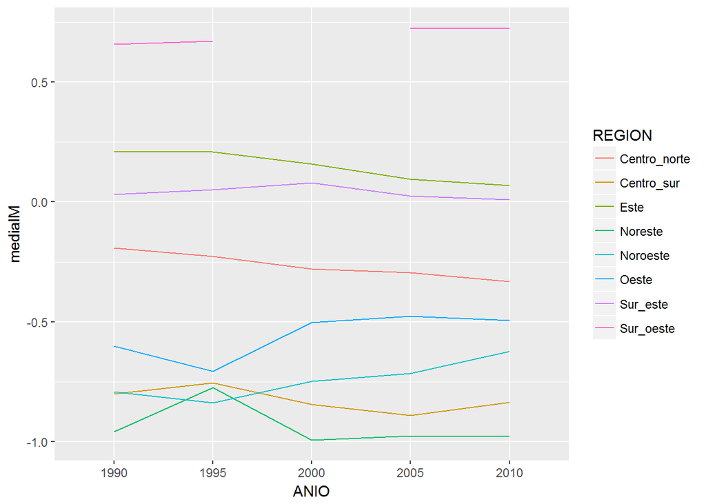

```r
#Con tabla_regiones cargada:

inner_join(base_marginacion, tabla_regiones, by="CVE_ENT") %>%
  mutate(ANIO=AÑO) %>%      #Pq group_by tiene problemas (a veces) con los acentos y ñ.
  filter(ANIO!="2015") %>%
  group_by(REGION, ANIO) %>%
  summarise (mediaIM=mean(IM)) %>%
  qplot(ANIO, mediaIM, group=REGION, color=REGION, data = ., geom="line")
```

[^1]: mpaladino@mora.edu.mx
[^2]: Podríamos hacer una lista, pero introduce una complejidad adicional innecesaria para este ejemplo.
[^3]: Se podría programar ese bucle haciendo que genere un vector que luego podemos adosar a la base de datos. Aún así sería más lento que cualquier función vectorizada.